# Случайный лес”

©ilykei.com., Balasanov Yu.,Doynikov A.,Nazarov L.

October 20, 2022

# Random forest

## Дерево решений

Дерево решений - средство поддержки принятия решений, использующееся в статистике. Структура дерева представляет собой «листья» и «ветки». На ребрах («ветках») дерева решения записаны атрибуты, от которых зависит целевая функция, в «листьях» записаны значения целевой функции, а в остальных узлах — атрибуты, по которым различаются случаи. Чтобы классифицировать новый случай, надо спуститься по дереву до листа и выдать соответствующее значение. Дерево принятия решений — это дерево, в листьях которого стоят значения целевой функции, а в остальных узлах — условия перехода (к примеру “ПОЛ есть МУЖСКОЙ”), определяющие по какому из ребер идти. Если для данного наблюдения условие истина, то осуществляется переход по левому ребру, если же ложь — по правому.

### Пример дерева решений в задаче классификации

Приведенный ниже пример дерева взят с сайта https://habrahabr.ru/post/116385/. Для примера рассмотрим дерево решений в задаче классификации.

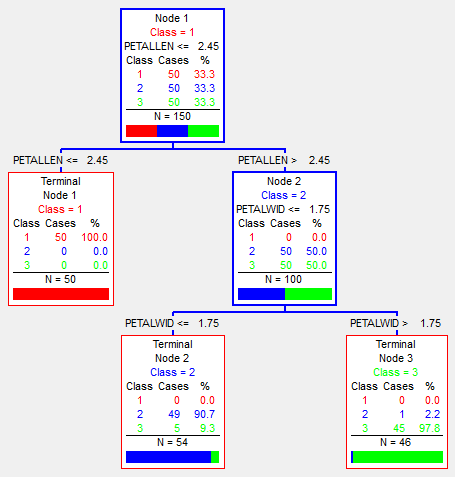

Classification tree

На изображении, приведенном выше показано дерево классификации ирисов. Классификация идет на три класса (на изображении помечены — красным, синим и зеленым), и проходит по параметрам: длина-толщина чашелистика (SepalLen, SepalWid) и длина-толщина лепестка (PetalLen, PetalWid). Как видим, в каждом узле стоит его принадлежность к классу (в зависимости от того, каких элементов больше попало в этот узел), количество попавших туда наблюдений N, а также количество каждого класса. Так же не в листовых вершинах есть условие перехода — в одну из дочерних. Соответственно, по этим условиям и разбивается выборка. В результате, это дерево почти идеально (6 из 150 неправильно) классифицировало исходные данные (именно исходные — те на которых оно обучалось).

### Пример дерева решений в задаче регрессии

Приведенный ниже пример дерева взят с сайта https://habrahabr.ru/post/116385/.

Если при классификации в листах стоят результирующие классы, при регрессии же стоит какое-то значение целевой функции.

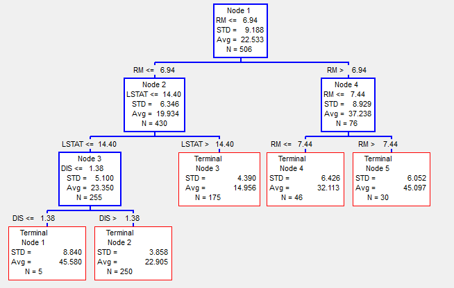

Regression tree

На выше приведенном изображении регрессионное дерево, для определения цены на землю в городе Бостон в 1978 году, в зависимости от параметров RM — количество комнат, LSTAT — процент неимущих и нескольких других параметров. Соответственно, здесь в каждом узле мы видим среднее значение (Avg) и стандартное отклонение (STD) значений целевой функции наблюдений, попавших в эту вершину. Общее количество наблюдений, попавших в узел N. Результатом регрессии будет то значение среднего (Avg), в какой узел попадёт наблюдение. Таким образом изначально классификационное дерево, может работать и для регрессии. Однако при таком подходе, обычно требуются большие размеры дерева, чем при классификации, чтобы достигнуть хороших результатов регрессии.

## Bagging

Leo Breiman в журнале Technical Report No. 421 (1994) https://www.cs.princeton.edu/courses/archive/fall08/cos402/readings/bagging.pdf предложили для повышения эффективности использования дерева решений комбинировать результаты нескольких деревьев из случайно сгенерированного подмножества тренировочных деревьев. Этот метод получил название Bagging (Bootstrap AGGregating). Обозначим:

$X$ - множеcтво объектов;

$Y$ - или конечное число классов, например, $A,B,C,D$ в задаче классификации или множество действительных чисел (случай регрессии);

$f:X→Y$ - отображение $X$ в $Y$;

$L=(x_1,f(x_1)),..,(x_m,f(x_m))$ - обучающая выборка;

$B^p=(L_1,...,L_p)$ - подмножества, полученные из обучающей выбрки, каждое размера $m$ путем случайного равномерного перемешивания $L$

Каждое обучающее множество $L_i$ генерирует предиктор (дерево) $f_i$ в регрессионной задаче простое среднее дает агрегированый предиктор.
$$f(x) = \frac{\sum_{i=1}^p f_i(x)}{p}$$
В задаче классификации популярный агрегированый предиктор выбирается большинством голосов. Пусть
$$N_Y(x)=
\sum_{i=1}^p I_{(f_i(x)= y})$$
где $I_A$-индикатор множества $A$.

Выражение для агрегированного предиктора
$$f(x)=argmax_{y \in Y}N_Y(x)$$
Эта процедура (bootstrap) приводит к модели с меньшеq дисперсией без смещения. Это означает, что если предсказание по одному дереву чувствительно к шуму, то среднее по многим деревьям нет.

## Random forest

Random Forest популярный метод машинного обучения (machine learning) предназначенный для решения задач регрессии, классификации и снижения размерности. Основные алгоритмы метода реализованы в библиотеке`library(randomForest)` другим пакетом, позволяющим работать и с пропущенными наблюдениями есть `library(randomForestSRC).

Дадим детальное описание алгоритма

1.Пусть размер обучаемого набора $L$ есть $n$. Тогда бутстрап выборки равномерно генерируются из $L$. Эти выборки будут тренировочными множествами для дерева

2.Пусть $M$ число внешних признаков. Построим решающее дерево, классифицирующее примеры данной подвыборки, причём в ходе создания очередного узла дерева будем выбирать признак, на основе которого производится разбиение, не из всех M признаков, а лишь из $m<M$ случайно выбранных. Выбор наилучшего из этих m признаков может осуществляться различными способами.

3.Алгоритм строит $N_{tree}$ деревьев. Каждое из которых берется максимально возможным и без обрезки ветвей. Что понимается под термином обрезка ветвей или стрижкой дерева. Стрижка дерева (pruning). Под этим понимается, что дерево сначала строится до максимальной глубины, потом постепенно, снизу-вверх, некоторые вершины дерева убираются за счет сравнения по качеству дерева с данным разбиением и без него (сравнение проводится с помощью кросс-валидации, о которой чуть ниже)

4.Предсказываем новые данные. Классификация объектов проводится путём голосования: каждое дерево выборки относит классифицируемый объект к одному из классов, и побеждает класс, за который проголосовало наибольшее число деревьев, при задаче регрессии берем среднее значение.

Число $m$ выбирается намного меньше $M$. Рекомендации здесь такие:

Для задачи классификации $m$ чаще всего берут равным $\sqrt{M}$.Минимальное число узлов равно 1.

В случае регрессии $m$ берут равным $M/3$.И минимальное число узлов равно 5

На практике эти параметры следует варьировать, настраивая модель.

Оптимальное число деревьев $N_{tree}$ подбирается таким образом, чтобы минимизировать ошибку классификатора на тестовой выборке.

Случайные леса работают при существенно многомерным числе переменных. Важно исследовать важность этих переменных. Случайные леса, получаемые в результате применения техник, описанных ранее, могут быть естественным образом использованы для оценки важности переменных в задачах регрессии и классификации.

Случайный лес моделирует выборку исходных данных с заменой. Здесь около трети данных не используются для обучения и могут быть использованы для тестирования. Этих неиспользованные данные, называют out-of-bag (OOB). А ошибку предсказания, полученную на них out-of-bag error (OOB error).

### Кросс-валидация

Модель обучается K раз на разных (K−1) подвыборках исходной выборки, а проверяется на одной подвыборке (каждый раз на разной). Получаются K оценок качества модели, которые обычно усредняются, выдавая среднюю оценку качества классификации/регрессии на кросс-валидации.

## Boosting

Термином “Boosting” называют набор алгоритмов, которые позволят слабых учеников сделать сильными.

### Gradient boosting trees

Cheng Li представил Градиентный Бустинг, который мы далее продемонстрируем на примере.

На каждом шаге процедуры бустинга дерево оценивается к остаткам предыдущего шага $r_x=f(x)−\widehat{f}(x)$ от предыдущего шага. Пусть

$$L(u,v)=(u−v)^2/2$$
функция потерь. От Бустинга требуется отрицательной производной функции потерь
$$\frac{∂L(f(x),\widehat{f}(x))}{∂\widehat{f}(x)}$$
Посмотрим Градиентный бустинг на следующем простом примере.

### Пример градиентного бустинга в задаче кластеризации

Пусть у нас есть синусоидальная волна с наложенным на нее шумом. Для начала получим такую волну

```r
set.seed(1180)
x<-seq(0,2*pi,by=.01)
sigmaEps<-.1
eps<-rnorm(length(x),0,sigmaEps)
signal<-sin(x)+eps
data<-data.frame(x=x,signal=signal)
head(data)
```

```
##      x      signal
## 1 0.00  0.15737361
## 2 0.01 -0.16510747
## 3 0.02 -0.04831630
## 4 0.03  0.06957697
## 5 0.04 -0.02137105
## 6 0.05  0.11559686
```

Cоздадим функцию, которая рисует первую и последнюю колонку из фрейма

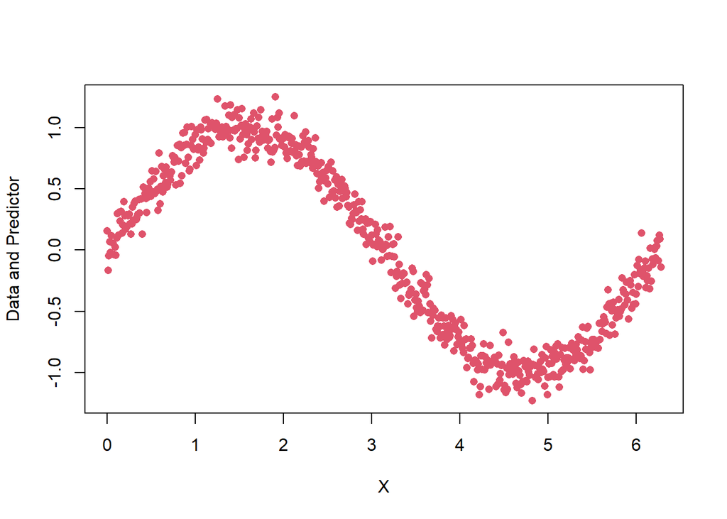

```r
myPlot<-function(myDataFrame){
  lastCol<-ncol(myDataFrame)
  matplot(myDataFrame$x,myDataFrame[,c(2,lastCol)],pch=16,xlab="X",ylab="Data and Predictor")
}
myPlot(data)
```

Просто поделим данные на два кластера при помощи стандартной процедуры классификации.

```r
suppressWarnings(library(mclust))
model<-Mclust(data$signal,G=2)
```

Посмотрим на результаты кластеризации

```r
summary(model)
```

```
## ----------------------------------------------------
## Gaussian finite mixture model fitted by EM algorithm
## ----------------------------------------------------
##
## Mclust E (univariate, equal variance) model with 2 components:
##
##  log-likelihood   n df       BIC       ICL
##       -583.6187 629  4 -1193.014 -1251.347
##
## Clustering table:
##   1   2
## 306 323
```

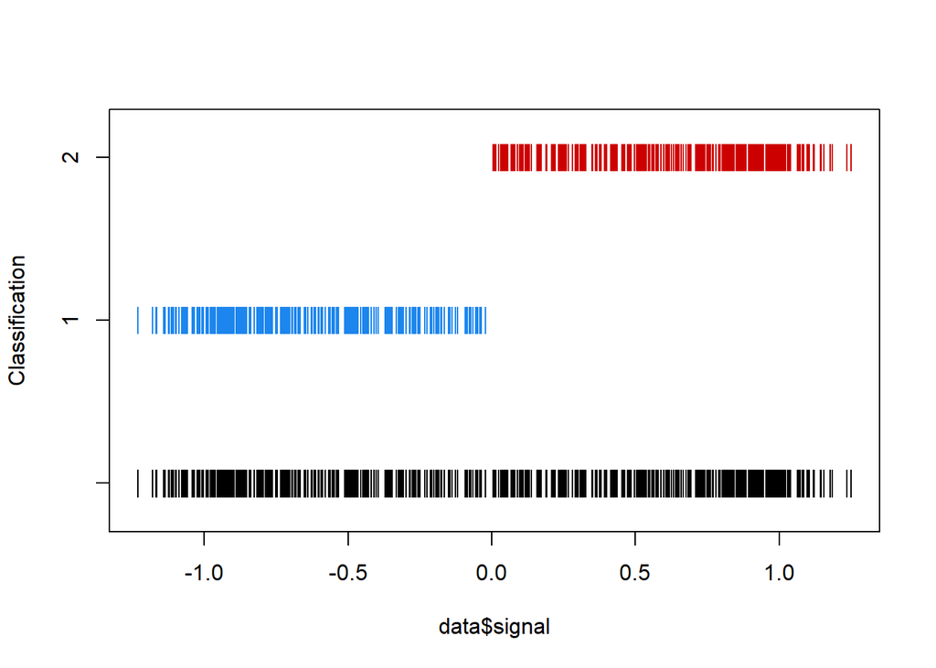

```r
plot(model, what="classification")
```

```r
model$parameters
```

```
## $pro
## [1] 0.4901664 0.5098336
##
## $mean
##          1          2
## -0.6454830  0.6191915
##
## $variance
## $variance$modelName
## [1] "E"
##
## $variance$d
## [1] 1
##
## $variance$G
## [1] 2
##
## $variance$sigmasq
## [1] 0.1136167
```

Кластеризация выделила две группы наблюдений отрицательную и положительную с одной и той же дисперсией.

Получим первую обученную выборку и поместим ее в добавленную к изначальному фпейму колонку.И нарисуем наш фрейм

```r
head(model$classification)
```

```
## [1] 2 1 1 2 1 2
```

```r
data$learner1<-model$parameters$mean[model$classification]
head(data)
```

```
##      x      signal   learner1
## 1 0.00  0.15737361  0.6191915
## 2 0.01 -0.16510747 -0.6454830
## 3 0.02 -0.04831630 -0.6454830
## 4 0.03  0.06957697  0.6191915
## 5 0.04 -0.02137105 -0.6454830
## 6 0.05  0.11559686  0.6191915
```

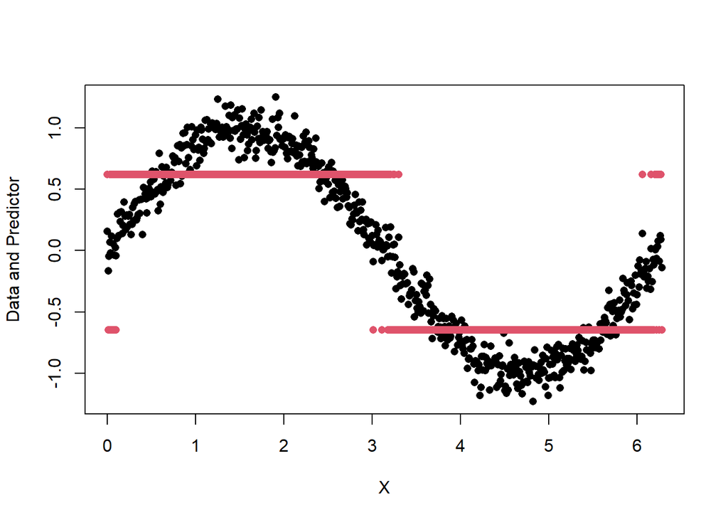

```r
myPlot(data)
```

Очевидно, что ученик слишком слаб, чтобы зафиксировать нелинейную картину сигнала, он только выделяет положительные и отрицательные кластеры точек.

Получим остатки от работы первого ученика.

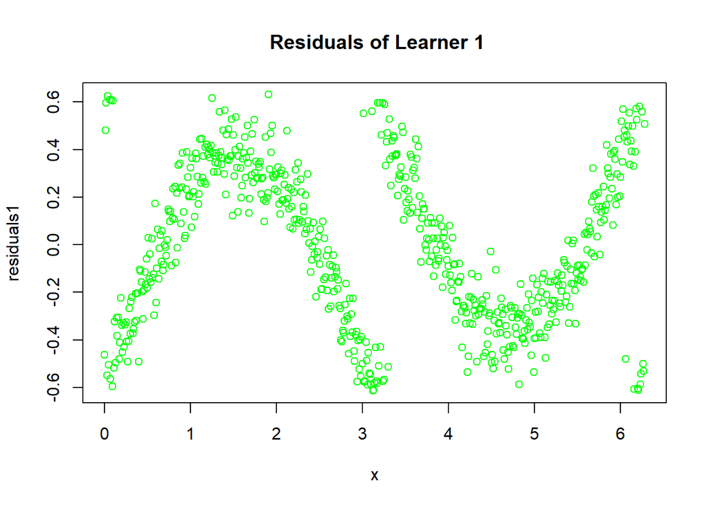

```r
residuals1<-data$signal-data$learner1
plot(x,residuals1,main= ' Residuals of Learner 1',col = 'green')
```

Посмотрим как различаются стандартные отклонения остатков и исходного сигнала

```r
sd1<-sd(residuals1)
c(sd(data$signal),sd1)
```

```
## [1] 0.7170284 0.3199656
```

Для того чтобы повторять шаги бустинга несколько раз создадим функцию, которая получает на вход сигнал разделяет его на 2 группы, используя Mclust() и возвращает вектор предсказаний для следующего ученика.

```r
simpleLearner<-function(mySignal){
  mod<-Mclust(mySignal,G=2)
  learner<-mod$parameters$mean[mod$classification]
  learner
}
```

Создадим вектор второго ученика как сумму колонки 1-го ученика разделения, полученного вторым учеником на вход которого предложили остатки первого ученика.

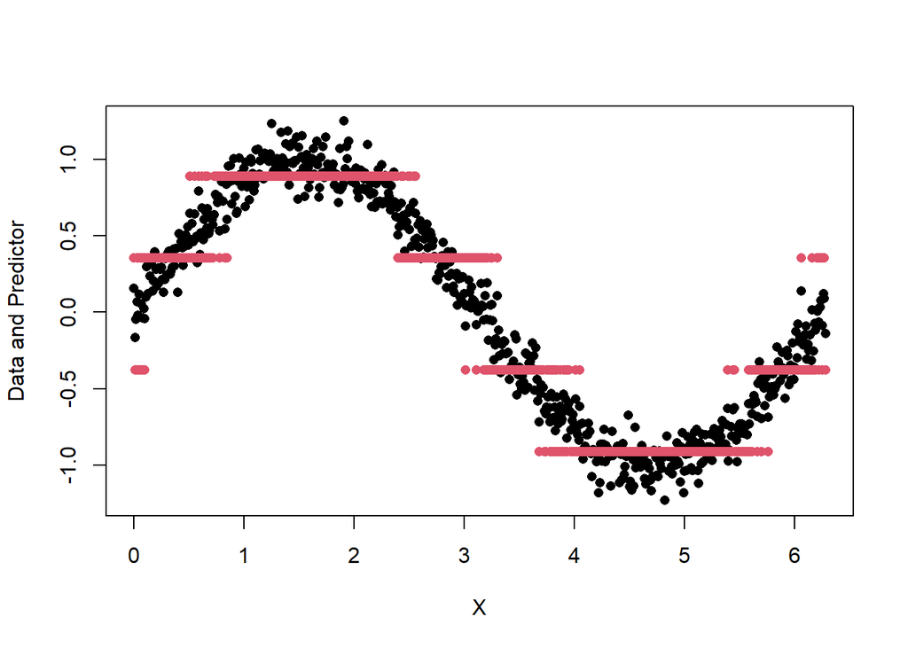

```r
data$learner12<-data$learner1+simpleLearner(residuals1)
myPlot(data)
```

Комбинация двух простых учеников дает намвозможность делить выборке на 4 кластера , что уже лучше описывает нелинейную волну синуса.

Получим остатки и будем повторять процедуру еще и еще.

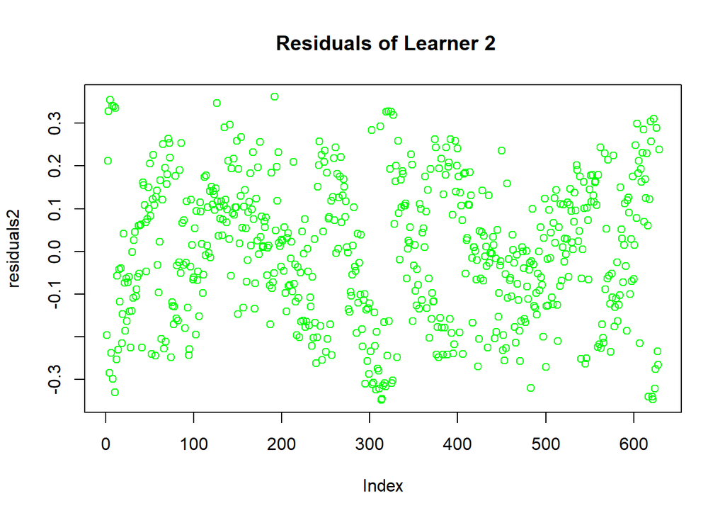

```r
residuals2<-data$signal-data$learner12
plot(residuals2,main= ' Residuals of Learner 2',col = 'green')
```

Следим при этом за изменением стандартного отклонения

```r
sd2<-sd(residuals2)
c(sd(data$signal),sd1,sd2)
```

```
## [1] 0.7170284 0.3199656 0.1599267
```

Опять получили существенное уменьшение стандартного отклонения.

Проведем еще одну итерацию.

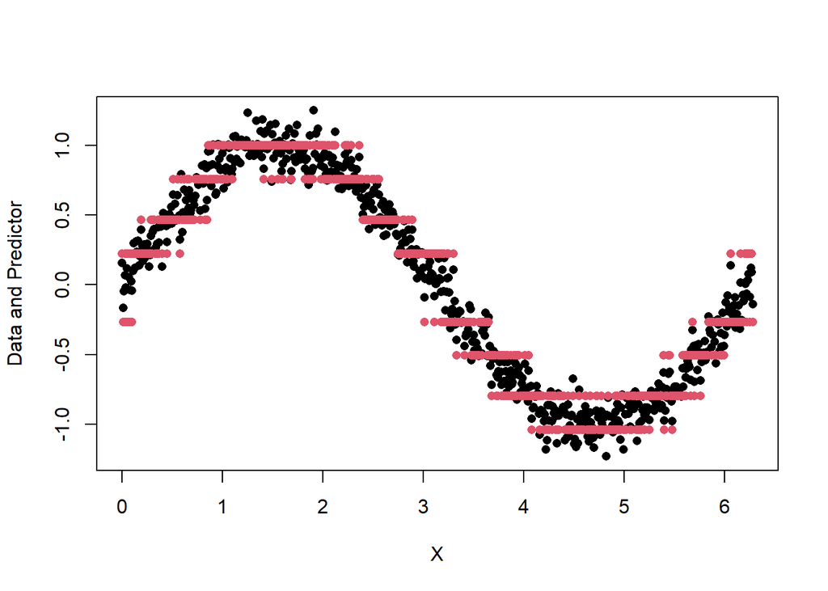

```r
data$learner123<-data$learner12+simpleLearner(residuals2)
myPlot(data)
```

Получили уже 8 уровней.Нелинейная волна изначального сигнала просматривается все лучше и лучше. Получим остатки

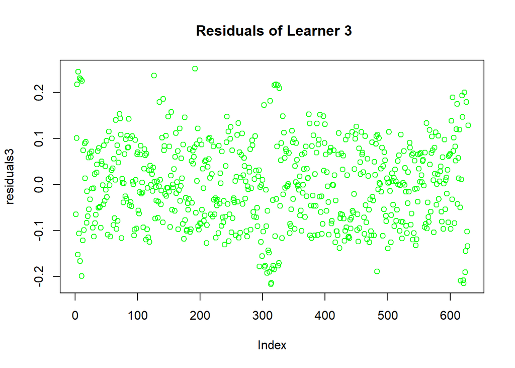

```r
residuals3<-data$signal-data$learner123
plot(residuals3,main= ' Residuals of Learner 3',col = 'green')
```

Опять следим за стандартным отклонением

```r
sd3<-sd(residuals3)
c(sd(data$signal),sd1,sd2,sd3)
```

```
## [1] 0.71702843 0.31996564 0.15992673 0.08886605
```

Еще одна итерация

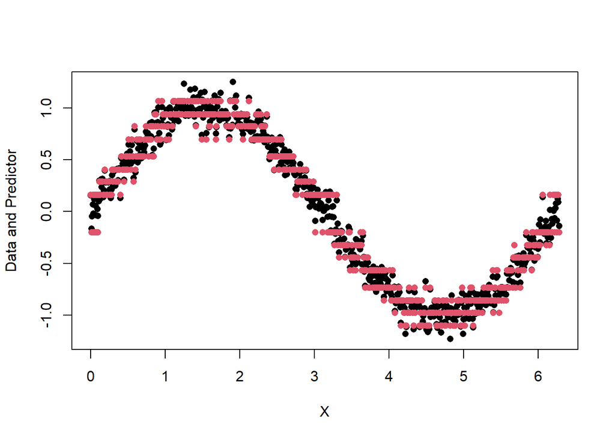

```r
data$learner1234<-data$learner123+simpleLearner(residuals3)
myPlot(data)
```

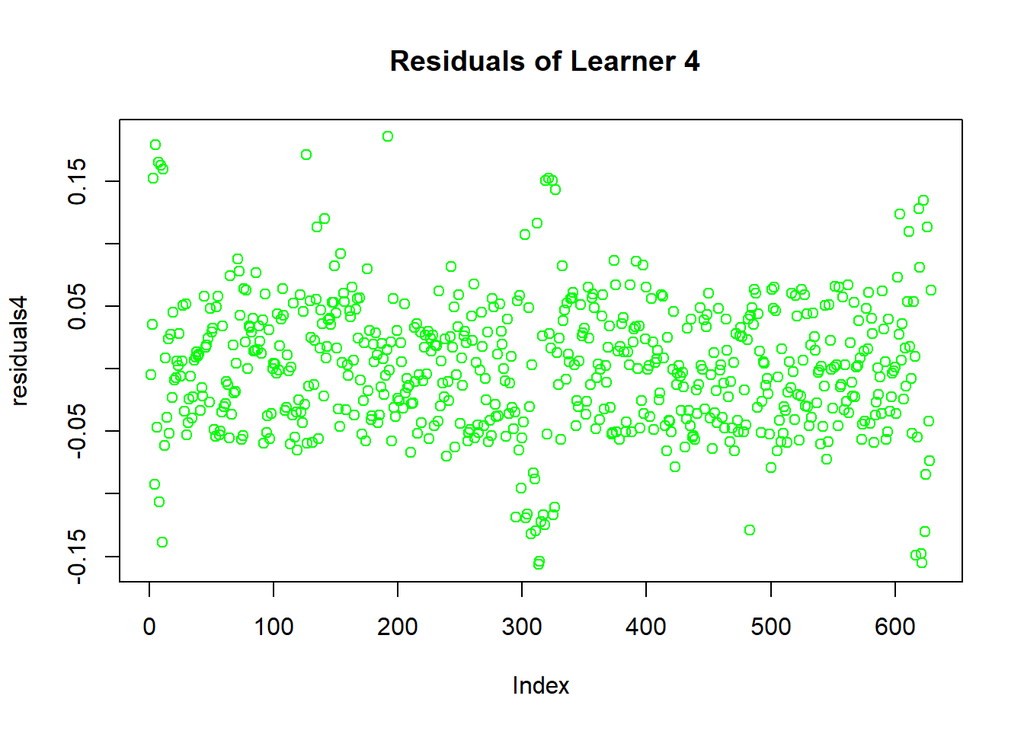

```r
residuals4<-data$signal-data$learner1234
plot(residuals4,main= ' Residuals of Learner 4',col = 'green')
```

Опять следим за стандартным отклонением

```r
sd4<-sd(residuals4)
c(sd(data$signal),sd1,sd2,sd3,sd4)
```

```
## [1] 0.71702843 0.31996564 0.15992673 0.08886605 0.05175807
```

И наконец выполним последнюю итерацию.

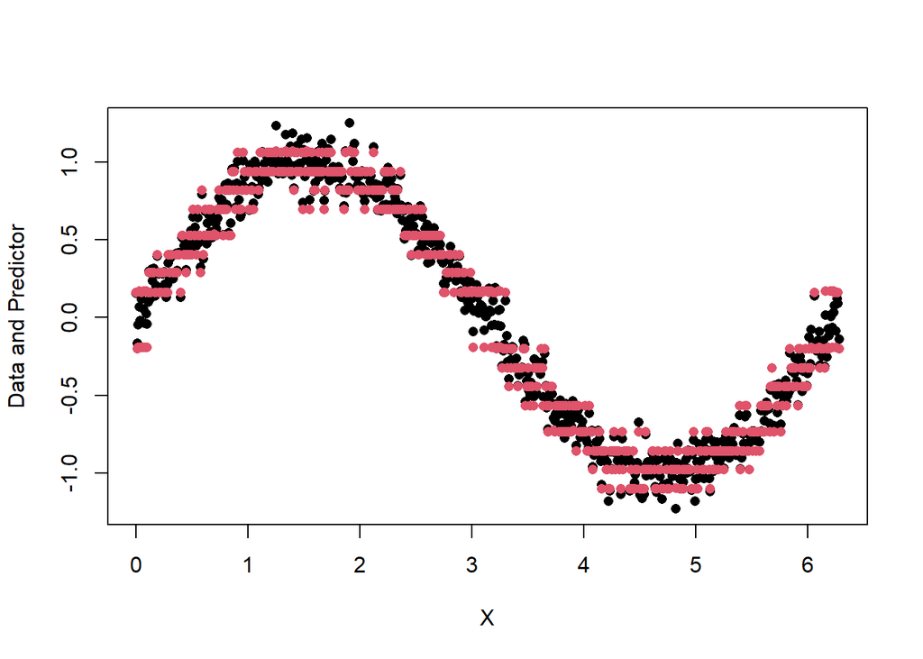

```r
data$learner12345<-data$learner1234+simpleLearner(residuals4)
myPlot(data)
```

Нелинейная структура сигнала отражена совсем уже хорошо. Остатки

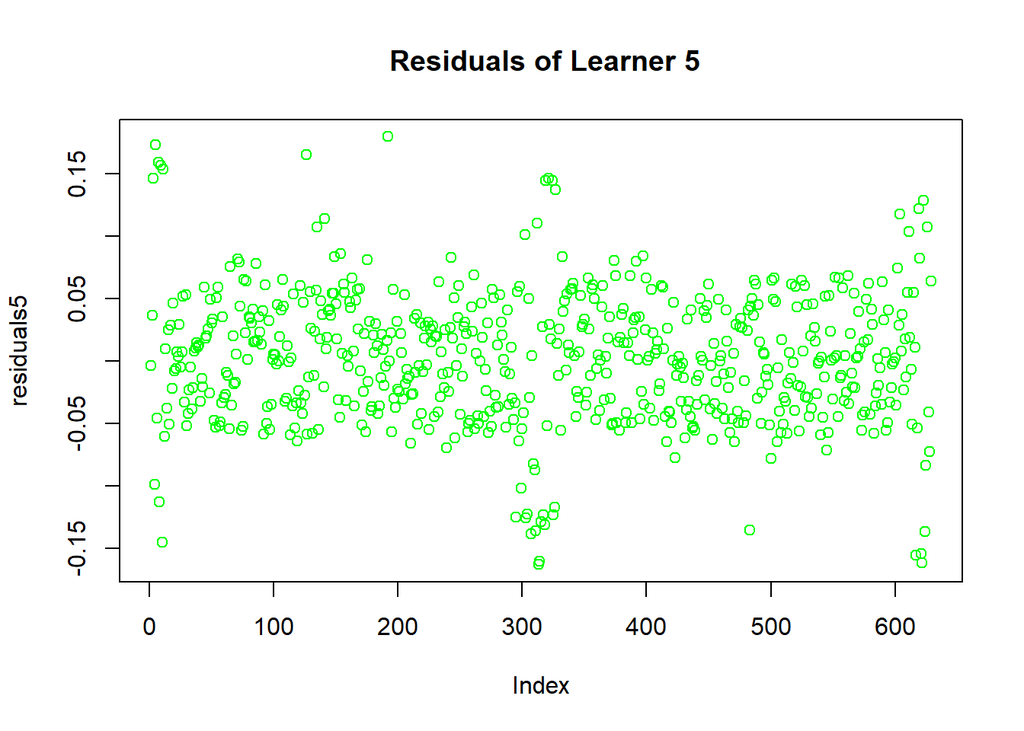

```r
residuals5<-data$signal-data$learner12345
plot(residuals5,main= ' Residuals of Learner 5',col = 'green')
```

Стандартные отклонения

```r
sd5<-sd(residuals5)
c(sd(data$signal),sd1,sd2,sd3,sd4,sd5)
```

```
## [1] 0.71702843 0.31996564 0.15992673 0.08886605 0.05175807 0.05168095
```

График изменений стандартных отклонений

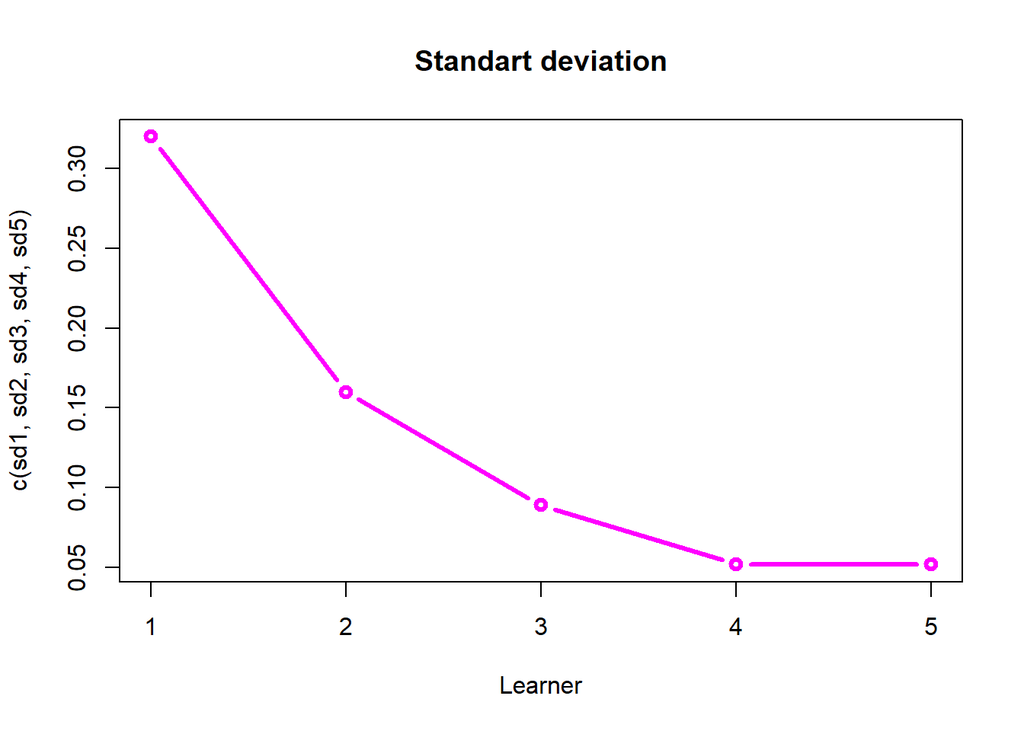

```r
plot(c(sd1,sd2,sd3,sd4,sd5),type="b",pch = 21,col = 'magenta',lty = 1,lwd = 3,main = 'Standart deviation',xlab = "Learner")
```

Заметим, что стандартное отклонение стало меньше, стандартное отклонение изначально наложенного шума $\epsilon_t=0.1$.

## Регрессия

### Предсказание заработной платы игроков

Мы используем данные Hitters из библиотеки ISLR.

```r
suppressWarnings(library(ISLR))
suppressWarnings(library(knitr))
```

Сначала уберем из данных пропущенные наблюдения и возьмем логарифм

```r
data(Hitters)
Hitters <- na.omit(Hitters)
Hitters$Salary <- log(Hitters$Salary)
kable(head(Hitters,3))
```

|  | AtBat | Hits | HmRun | Runs | RBI | Walks | Years | CAtBat | CHits | CHmRun | CRuns | CRBI | CWalks | League | Division | PutOuts | Assists | Errors | Salary | NewLeague |
| --- | --- | --- | --- | --- | --- | --- | --- | --- | --- | --- | --- | --- | --- | --- | --- | --- | --- | --- | --- | --- |
| -Alan Ashby | 315 | 81 | 7 | 24 | 38 | 39 | 14 | 3449 | 835 | 69 | 321 | 414 | 375 | N | W | 632 | 43 | 10 | 6.163315 | N |
| -Alvin Davis | 479 | 130 | 18 | 66 | 72 | 76 | 3 | 1624 | 457 | 63 | 224 | 266 | 263 | A | W | 880 | 82 | 14 | 6.173786 | A |
| -Andre Dawson | 496 | 141 | 20 | 65 | 78 | 37 | 11 | 5628 | 1575 | 225 | 828 | 838 | 354 | N | E | 200 | 11 | 3 | 6.214608 | N |

## Random Forest

Метод случайного леса мы будем брать из R библиотеки library(randomForest). Description: Библиотека randomForest реализует алгоритм Breiman и Cutler первоначально написанный на фортране для решения задач регрессии и классификации. Инструкцию к библиотеке можно посмотреть здесь https://cran.r-project.org/web/packages/randomForest/randomForest.pdf . Зададим датчик случайных чисел и начинаем выращивать лес.

```r
set.seed(0)
library(randomForest)
rfSalary <- randomForest(Salary~.,ntree=500, data=Hitters,importance=TRUE)
print(rfSalary)
```

```
##
## Call:
##  randomForest(formula = Salary ~ ., data = Hitters, ntree = 500,      importance = TRUE)
##                Type of random forest: regression
##                      Number of trees: 500
## No. of variables tried at each split: 6
##
##           Mean of squared residuals: 0.1797216
##                     % Var explained: 77.18
```

Статистиску “mean of squared residuals” обозначим $MSE_{OOB}$ вычисляется на основе out-of-bag выборки.

Статистика “% Var explained” это
$$100(1-\frac{MSE_{OOB}}{\widehat\sigma^2_y})$$
где OOB оценка для $\widehat\sigma^2_y$ вычисляется делением на $n$, а не на $n-1$. Пакет включает функцию importance() для определения меры важности каждой переменной

Мера важности определяется следующим образом.Показатель рассчитывается по OOB данным для каждого из деревьев получают ошибки предсказания (частота ошибок классификации, регрессии).То же самое делается после каждой перестановки переменных-предикторов. Разница между ошибками усредняется по всем деревьям и нормализуется стандартным отклонением различий.В основе меры важности лежит следующее : если предиктор не важен, перестановка его значений не сделает предсказание хуже.

Вторая мера важности - это общее уменьшение числа узлов при расщеплении на переменной, усредненное по всем деревьям. Для классификации это измеряют индексом Джини .Индекс Джини вычисляется по предсказаниям.

#### Неопределенность Джини (Gini impurity)

Неопеределенность по Джини вычисляется по формуле
$$G=1−\sum_k{p_k}^2$$
. Максимизацию этого критерия можно интерпретировать как максимизацию числа пар объектов одного класса, оказавшихся в одном поддереве. Еще одна мера качества это

Ошибка классификации (misclassification error):
$$E=1−\max_kp_k$$
На практике ошибка классификации почти не используется, а неопределенность Джини работет часто.

В случае задачи бинарной классификации ($p_{+}$ – вероятность объекта иметь метку $+$) неопределенность Джини примет следующий вид:
$$G=1−p_{+}^2−p_{-}^2=1−p_+^2−[1−p_+]^2=2p_+(1−p_+)$$
.

При регрессии качество оценки определяют средней суммой квадратов остатков.

Посмотрим важность переменных входящих в модель.

```r
importance(rfSalary)
```

```
##               %IncMSE IncNodePurity
## AtBat     11.04473170     7.8273993
## Hits       8.14875343     8.3361150
## HmRun      4.05788047     2.7904848
## Runs       8.57518525     5.4225820
## RBI        6.96549878     6.5984694
## Walks      9.95461274     6.4594625
## Years     10.97301275     7.7202911
## CAtBat    17.22770590    38.9365723
## CHits     17.14070336    35.8528658
## CHmRun     8.14862853     7.7629311
## CRuns     14.68631048    31.3141380
## CRBI      13.70222745    19.9732594
## CWalks    10.36356473    17.8513066
## League    -0.15644265     0.2771139
## Division   0.05418096     0.2544020
## PutOuts    3.18723063     3.1526201
## Assists    0.63876373     1.6713038
## Errors     2.40006727     1.6814031
## NewLeague  0.33641580     0.3798795
```

Возможно сортировка переменных по важности

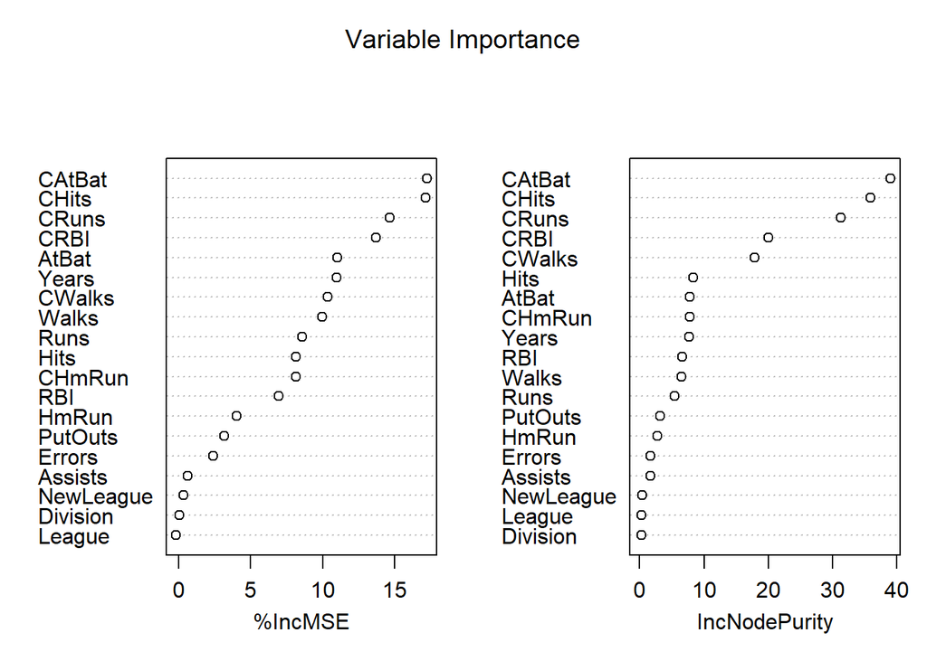

```r
varImpPlot(rfSalary, main="Variable Importance")
```

Также можно посмотреть график зависимости ошибки от количества деревьев

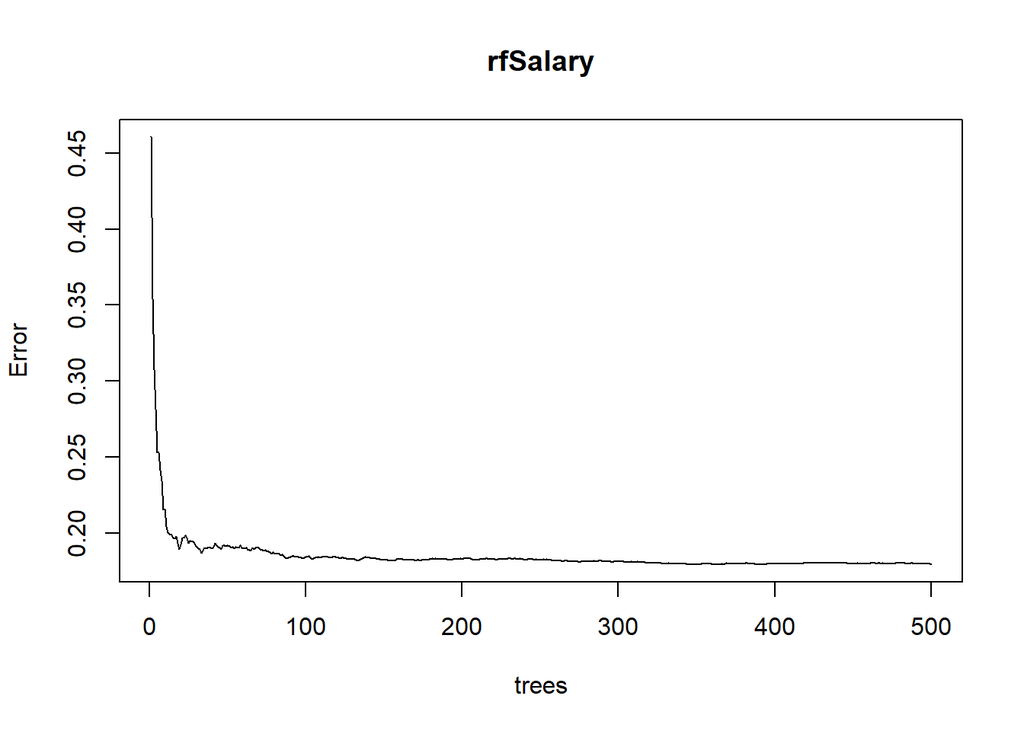

```r
plot(rfSalary)
```

### Сокрашение количества деpевьев

Сравним лес из 500 деревьев и 200 деревьев.

```r
set.seed(0)
rfSalary200 <- randomForest(Salary~., ntree=200, data=Hitters,importance=TRUE)
print(rfSalary200)
```

```
##
## Call:
##  randomForest(formula = Salary ~ ., data = Hitters, ntree = 200,      importance = TRUE)
##                Type of random forest: regression
##                      Number of trees: 200
## No. of variables tried at each split: 6
##
##           Mean of squared residuals: 0.183184
##                     % Var explained: 76.74
```

```r
rbind(T200=c(mse=tail(rfSalary200$mse,1),rsq=tail(rfSalary200$rsq,1)),
               T500=c(mse=tail(rfSalary$mse,1),rsq=tail(rfSalary$rsq,1)))
```

```
##            mse       rsq
## T200 0.1831840 0.7674318
## T500 0.1797216 0.7718275
```

Посмотрим изменилась ли относительная важность переменных?

```r
cbind(T200=row.names(rfSalary200$importance),T500=row.names(rfSalary$importance))
```

```
##       T200        T500
##  [1,] "AtBat"     "AtBat"
##  [2,] "Hits"      "Hits"
##  [3,] "HmRun"     "HmRun"
##  [4,] "Runs"      "Runs"
##  [5,] "RBI"       "RBI"
##  [6,] "Walks"     "Walks"
##  [7,] "Years"     "Years"
##  [8,] "CAtBat"    "CAtBat"
##  [9,] "CHits"     "CHits"
## [10,] "CHmRun"    "CHmRun"
## [11,] "CRuns"     "CRuns"
## [12,] "CRBI"      "CRBI"
## [13,] "CWalks"    "CWalks"
## [14,] "League"    "League"
## [15,] "Division"  "Division"
## [16,] "PutOuts"   "PutOuts"
## [17,] "Assists"   "Assists"
## [18,] "Errors"    "Errors"
## [19,] "NewLeague" "NewLeague"
```

### Вариация числа переменных

```r
mtryVec<-1:19
set.seed(0)
mtryQuality<-t(sapply(mtryVec,
                      function(z) c(mse=tail(randomForest(Salary~.,
                                                          ntree=200,
                                                          data=Hitters,
                                                          importance=T,mtry=z)$mse,1),
                                    rsq=tail(randomForest(Salary~.,
                                                          ntree=200,

                                                                                                                data=Hitters,
                                                          importance=T,
                                                          mtry=z)$rsq,1)
                                    )
                      )
               )
head(mtryQuality)
```

```
##            mse       rsq
## [1,] 0.2160327 0.7335060
## [2,] 0.1874388 0.7733105
## [3,] 0.1864688 0.7714732
## [4,] 0.1844576 0.7679577
## [5,] 0.1769003 0.7765539
## [6,] 0.1847133 0.7700715
```

## Регрессия с большим числом предикторов

Рассмотрим пример когда случайный лес строится к регрессионной модели с большим числом прдикторов. Для начала моделируем данные

```r
N = 500
set.seed(0)
Epsilon<-rnorm(N,0,1)
X<-rnorm(N*N,0,2)
dim(X)<-c(N,N)
colnames(X)<-paste0("X",1:N)
slopesSet<-runif(N,1,3)
Y<-sapply(2:N,function(z) 1+X[,1:z]%*%slopesSet[1:z]+Epsilon)
head(X[,1:5])
```

```
##              X1         X2         X3          X4         X5
## [1,] -1.2527365 -0.5737031  0.1575234  0.88869164 -1.0643804
## [2,]  0.9626707  3.6822138 -0.1028412  0.02385876 -0.7399334
## [3,]  3.3905422 -0.3135286 -0.5215483 -0.01856009  2.3417986
## [4,] -3.5224526 -2.7796053  3.1325364 -0.60475511 -0.9291356
## [5,]  0.3960260 -2.9462080 -0.7440302  0.98471004 -0.6042920
## [6,]  0.7946982 -0.1390379  3.4838889 -1.20543924  2.7827418
```

```r
m = 440
completeModelDataFrame <- data.frame(Y=Y[,m-1],X[,1:m])
```

Оцениваем случайный лес

```r
library(randomForest)
set.seed(0)
rfManyReg <- randomForest(Y~., data=completeModelDataFrame)
print(rfManyReg)
```

```
##
## Call:
##  randomForest(formula = Y ~ ., data = completeModelDataFrame)
##                Type of random forest: regression
##                      Number of trees: 500
## No. of variables tried at each split: 146
##
##           Mean of squared residuals: 7018.218
##                     % Var explained: 6.78
```

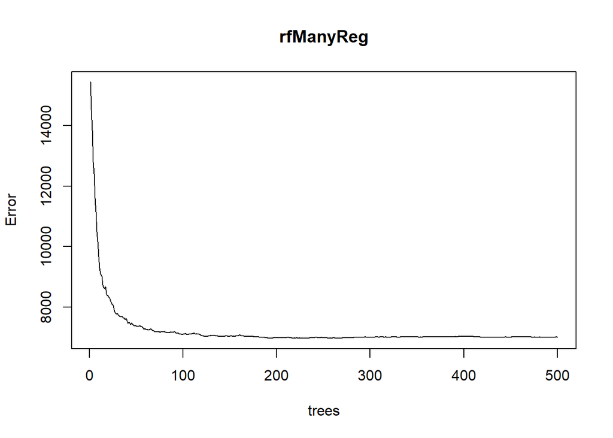

```r
plot(rfManyReg)
```

Посмотрим при каком числе деревьев средняя сумма квадратов ошибок минимальна

```r
which.min(rfManyReg$mse)
```

```
## [1] 267
```

А где минимум первой сотни деревьев

```r
which.min(rfManyReg$mse[1:100])
```

```
## [1] 99
```

```r
set.seed(0)
rfManyReg <- randomForest(Y~., data=completeModelDataFrame,ntree=which.min(rfManyReg$mse[1:100]))
print(rfManyReg)
```

```
##
## Call:
##  randomForest(formula = Y ~ ., data = completeModelDataFrame,      ntree = which.min(rfManyReg$mse[1:100]))
##                Type of random forest: regression
##                      Number of trees: 99
## No. of variables tried at each split: 146
##
##           Mean of squared residuals: 7105.823
##                     % Var explained: 5.62
```

Сравним с обычной регрессией

```r
lmManyReg <- lm(Y~., data=completeModelDataFrame)
sum(lmManyReg$residuals^2)
```

```
## [1] 49.58597
```

```r
sum(lmManyReg$residuals^2)/length(lmManyReg$residuals)
```

```
## [1] 0.09917195
```

## Классификация

### Otto Product пример классификациии

В этом примере мы будем использовать данные прдставленные Otto Group для Kaggle соревнования.

Otto Group необходимо категоризировать около 200,000 неустановленных продуктов в 9 классов основываясь на 93 признаках . Для простоты мы сократим чило классов.

Прочитаем данные

```r
datapath <- './'
suppressWarnings(library(fBasics))
Data = read.csv(paste(datapath,'DTTrain.csv',sep='/'),header=TRUE)
dim(Data) # dataset dimensions
```

```
## [1] 10233    95
```

```r
kable(head(Data[,1:5],3))
```

| time | feat_1 | feat_2 | feat_3 | feat_4 |
| --- | --- | --- | --- | --- |
| 45652 | 0 | 0 | 0 | 0 |
| 225646 | 0 | 0 | 0 | 0 |
| 345735 | 0 | 0 | 0 | 0 |

```r
kable(Data[1:3,(ncol(Data)-4):ncol(Data)])
```

| feat_90 | feat_91 | feat_92 | feat_93 | target |
| --- | --- | --- | --- | --- |
| 0 | 0 | 1 | 0 | Class_5 |
| 0 | 1 | 1 | 0 | Class_3 |
| 0 | 0 | 0 | 0 | Class_5 |

Разделим данные на две части в соотношении 2/3 и 1/3 на тренировочные данные и тестовые данные, равномерно перемешав их перед этим.

```r
set.seed(13)
testInd = sample(nrow(Data), nrow(Data)/3)
Data$target <- as.factor(Data$target)

xTrain = Data[-testInd,-1]

xTest = Data[testInd,-1]
yTrain = as.factor(Data$target[-testInd])
yTest = Data$target[testInd]
```

### Random forest

Оценим случайный лес к тренировочным данным и сделаем предсказание к тестовым данным.

```r
rfOtto <- randomForest(target~., data=xTrain,ntree=100)
rfPred <- predict(rfOtto, xTest, type="prob")
rfPred[1:5,]
```

```
##      Class_1 Class_2 Class_3 Class_4 Class_5
## 9152    0.22    0.06    0.00    0.07    0.65
## 5989    0.38    0.08    0.08    0.03    0.43
## 717     0.19    0.19    0.01    0.12    0.49
## 4870    0.00    0.00    1.00    0.00    0.00
## 944     0.00    0.99    0.00    0.01    0.00
```

Если нам нужны непосредственно прогнозы классов, то type =“response” .

```r
rfPredTest <- predict(rfOtto, xTest, type="response")
head(rfPredTest)
```

```
##    9152    5989     717    4870     944    8086
## Class_5 Class_5 Class_5 Class_3 Class_2 Class_2
## Levels: Class_1 Class_2 Class_3 Class_4 Class_5
```

Будем использовать Multiclass logloss для оценки качества предсказания.В русскоязычной литературе logloss нызывают `логистическая функция ошибки’.

### Мера качества разбиения Multiclass logloss

Пусть $N$ число объектов для классификации, a $M$ - число классов. Пусть также переменная $y_{i,j}$ принимает значение 1, если $i$ объект с этим номером принадлежит классу $j$, иначе 0. Пусть также $p_{i,1},...,p_{i,M}$ предсказывает вероятности того, что объект $i$ принадлежит одному из классов. Вектор $p_{i,1},...,p{i,M}$ это обычная выходная переменная методов классификации.

Популярной мерой для оценки качества классификации является так называемый logloss. Формула которого

$$logloss=-\frac{\sum_{i=1}^N y_{i,j}ln
(p_{i,j})}{N}$$
Например, пусть число классов $N=2$ и у нас только один объект для классификации, тогда
$$logloss=−y_{1,1}ln(p_{1,1})−y_{1,2}ln(p_{1,2})$$
.

logloss часто используется в виде штрафной функции при сравнении различных решений задач классификации.

Отметим неприятное свойство logloss: если для объекта 1го класса мы предсказываем нулевую вероятность принадлежности к этому классу или, наоборот, для объекта 0го – единичную вероятность принадлежности к классу 1, то ошибка равна бесконечности! Таким образом, грубая ошибка на одном объекте сразу делает алгоритм бесполезным. На практике часто logloss ограничивают каким-то большим числом (чтобы не связываться с бесконечностями).

Напишем эту функцию

```r
MultiLogLoss <- function(y,p)
{
  nrow <- dim(y)[1]
  ncol <- dim(y)[2]
  s <- NA
  p0 <- ifelse(p != 0,p,1)
  if ((nrow == dim(p)[1]) &&  (ncol == dim(p)[2]))
  {
     s <- -sum( y * log(p0))/nrow
  }
  return(s)
}
```

Вычислим logloss для построенного случайного леса.

Нам понадобится библиотека dummies, которая к сожалению удалена из репозитория CRAN, но ее можно учтановить вручную, предварительно скачав из архива.

```r
#install.packages("dummies_1.5.6.tar.gz", repos = NULL, type="source")
suppressWarnings(library(dummies))
```

Создадм матрицу правильной классификации используя функцию dummy.data.frame() из библиотеки dummies.

```r
rf_target_IndMat<-dummy.data.frame(data=as.data.frame(yTest),
                                     sep="_", verbose=F,
                                     dummy.class="ALL")
rf_target_IndMat[1:10,]
```

```
##    yTest_Class_1 yTest_Class_2 yTest_Class_3 yTest_Class_4 yTest_Class_5
## 1              0             0             0             0             1
## 2              1             0             0             0             0
## 3              0             0             0             0             1
## 4              0             0             1             0             0
## 5              0             1             0             0             0
## 6              0             1             0             0             0
## 7              0             0             0             0             1
## 8              0             0             0             1             0
## 9              0             1             0             0             0
## 10             0             0             1             0             0
```

Тогда logloss будет равна:

```r
(rfLogLoss = MultiLogLoss(rf_target_IndMat,rfPred))
```

```
## [1] 0.369506
```

### Gradient boosting

Функция xgboost() поддерживает переменные типа числовые матрицы и не поддерживает тип data frames поэтому мы переведем классы в целое число.

Делаем необходимые преобразования.

```r
library(xgboost)
xgbTrain = data.matrix(xTrain[,-ncol(xTrain)])
xgbTest = data.matrix(xTest[,-ncol(xTest)])
yTrain = as.integer(yTrain)-1
yTest = as.integer(yTest)-1
table(yTrain)
```

```
## yTrain
##    0    1    2    3    4
##  650 2635  927  990 1620
```

```r
numClasses = max(yTrain) + 1
param <- list("objective" = "multi:softprob",
              "eval_metric" = "mlogloss",
              "num_class" = numClasses)
```

Параметр “objective” = “multi:softprob” обеспечит обощение логистической функции связи для множественных классов и поэтому на выходе будет матрица вероятностей каждого класса, при заданиии “objective” = “multi:softmax” ворзвращается класс , чья вероятность максимальна.

Важно использовать кросс- валидацию, чтобы протестировать модель, например, для того, чтобы найти оптимальное количество итераций. В библиотеке xgboost это делается функцией xgb.cv().

Оценим бустинг модель.

```r
cv.nround <- 10
cv.nfold <- 3
set.seed(1)
(bst.cv = xgb.cv(param=param, data = xgbTrain, label = yTrain,
                nfold = cv.nfold, nrounds = cv.nround,verbose=F))
```

```
## ##### xgb.cv 3-folds
##  iter train_mlogloss_mean train_mlogloss_std test_mlogloss_mean
##     1           1.1633396       0.0017696358          1.1883907
##     2           0.9232930       0.0009158111          0.9658685
##     3           0.7625694       0.0031413699          0.8204235
##     4           0.6461203       0.0036960982          0.7139777
##     5           0.5580790       0.0035756571          0.6346756
##     6           0.4911672       0.0029174583          0.5746057
##     7           0.4376325       0.0026616750          0.5285550
##     8           0.3947157       0.0031888771          0.4922291
##     9           0.3590817       0.0048939732          0.4638751
##    10           0.3285080       0.0051704431          0.4403093
##  test_mlogloss_std
##        0.004829497
##        0.009605356
##        0.010354883
##        0.011473021
##        0.010616274
##        0.009800686
##        0.010211014
##        0.010975056
##        0.010580256
##        0.011681395
```

Сделаем предсказание вероятностей классов с этим числом nrounds = 10.

```r
bst = xgboost(param=param, data = xgbTrain, label = yTrain,
              nrounds=cv.nround,verbose=F)
xgbPred <- matrix(predict(bst, xgbTest), ncol = numClasses, byrow = TRUE)
head(xgbPred)
```

```
##            [,1]       [,2]       [,3]       [,4]       [,5]
## [1,] 0.07005556 0.06218502 0.02946227 0.06553441 0.77276278
## [2,] 0.52333015 0.13315237 0.07728224 0.13396128 0.13227394
## [3,] 0.20102398 0.15436779 0.03727620 0.07015130 0.53718072
## [4,] 0.01824003 0.01389743 0.93387479 0.01442061 0.01956707
## [5,] 0.02718644 0.91611904 0.01296168 0.02706998 0.01666282
## [6,] 0.02519860 0.91257602 0.01502645 0.01869680 0.02850214
```

Сравним logloss моделей случайного леса и случайного леса с бустингом

```r
gb_target_IndMat<-dummy.data.frame(data=as.data.frame(yTest),
                                     sep="_", verbose=F,
                                     dummy.class="ALL")
print(list(RF = rfLogLoss ,XGB = MultiLogLoss(gb_target_IndMat,xgbPred)))
```

```
## $RF
## [1] 0.369506
##
## $XGB
## [1] 0.4249591
```

Можно поиграть параметрами nrounds, nfold и добиться чтобы модель стала лучше по logloss , чем случайный лес. Например:

```r
cv.nround <- 20
bst.cv = xgb.cv(param=param, data = xgbTrain, label = yTrain,
                nfold = cv.nfold, nrounds = cv.nround,verbose=F)
bst = xgboost(param=param, data = xgbTrain, label = yTrain,
              nrounds=cv.nround,verbose=F)
xgbPred <- matrix(predict(bst, xgbTest), ncol = numClasses, byrow = TRUE)
print(list(RF = rfLogLoss ,XGB = MultiLogLoss(gb_target_IndMat,xgbPred)))
```

```
## $RF
## [1] 0.369506
##
## $XGB
## [1] 0.3232496
```

## Задача регрессии. Прогноз результатов ЕГЭ.

Посмотрим на применение `random forest` к задаче регрессии прогноза адекватности знаний и полученной оценке ЕГЭ по математике.

Читаем данные, делим их на две части `тренировочную` и `тестовую`

```r
library(randomForest)
Path = './'
fName <- paste0(Path,"ANOVA.csv")
Students <-read.csv(fName,sep = ",")
Students <-Students[Students$EGE> 0,]
StudentsForest <- Students[,2:5]
set.seed(20)
d = sort(sample(nrow(StudentsForest), nrow(StudentsForest)*.9))
train <- StudentsForest[d,]
train <- as.data.frame(train)
test<-StudentsForest[-d,]
```

Заметим, что здесь входные данные необходимо оформить как `data.frame`. Выращиваем лес из 500 деревьев для регресиии результатов ЕГЭ от предикторов:результатов ДВИ и контрольных работ.  
Смотрим на важность ппредикторов

```r
train <- data.frame(train)
rf_train <- randomForest(EGE~.,ntree=500, data=train,importance=TRUE)
print(rf_train)
```

```
##
## Call:
##  randomForest(formula = EGE ~ ., data = train, ntree = 500, importance = TRUE)
##                Type of random forest: regression
##                      Number of trees: 500
## No. of variables tried at each split: 1
##
##           Mean of squared residuals: 74.62316
##                     % Var explained: 19.25
```

```r
importance(rf_train)
```

```
##            %IncMSE IncNodePurity
## DVI     26.6638130      5942.041
## ALGEBRA 18.9582757      3559.857
## GEOM    -0.8803213      1257.329
```

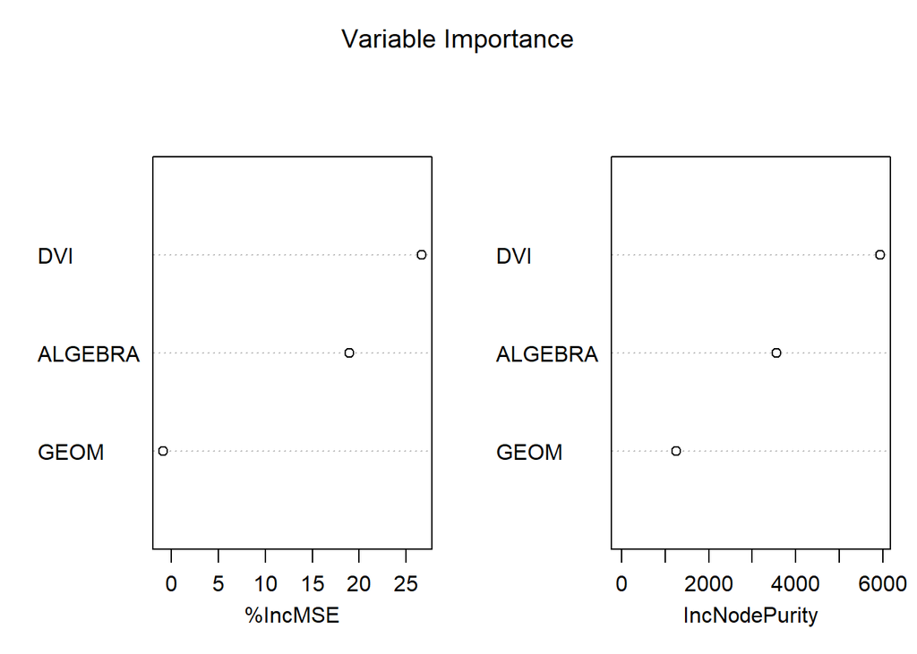

```r
varImpPlot(rf_train, main="Variable Importance")
```

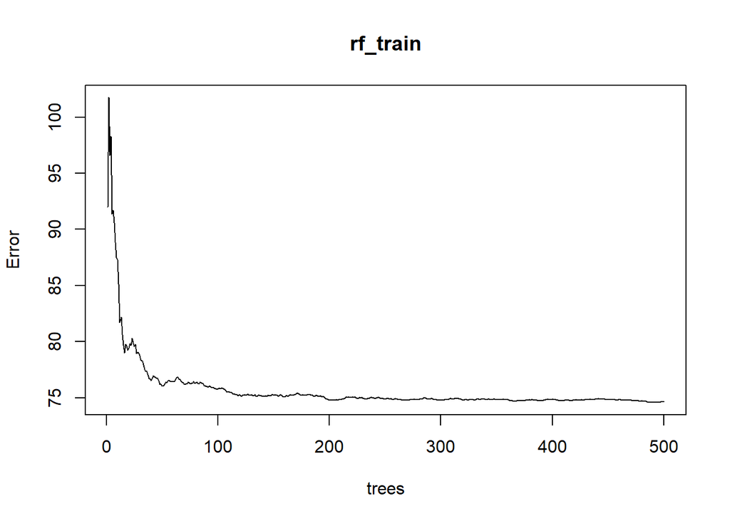

```r
plot(rf_train)
```

Заметим, что здесь мы получаем результат, аналогичный тому, что мы получали при дисперсионном анализе (ANOVA). Теперь предсказание для тестовой выборки

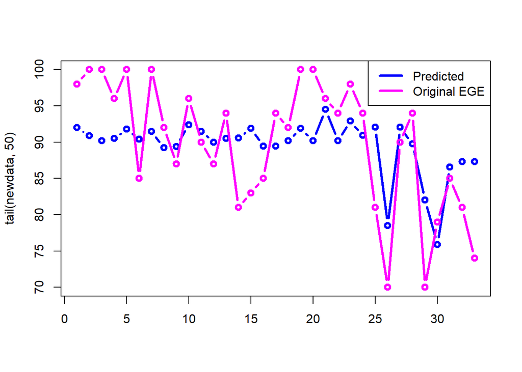

```r
predicted  <- predict(rf_train,newdata = test)
newdata <-cbind(predicted,test$EGE)
matplot(tail(newdata,50),type = "b",pch=21,col = c("blue","magenta"),lty = c(1,1),lwd = 3)
legend("topright",legend=c("Predicted","Original EGE"),col = c("blue","magenta"),lty = c(1,1),lwd = 3)
```

Посмотрим корреляцию предсказанных отметок ЕГЭ и реальных в тестовой выборке

```r
cor(predicted,test$EGE)
```

```
## [1] 0.6806131
```

Сравним с результатами предыдущей лекции. Заметим, что результат чуть хуже, чем дает обычная регрессия и нейронная сеть